# Reproducible Research: Peer Assessment 1

The assigment uses data from a wearable device to count steps of a person for a long period of time and gives the opportunity to study different aspect from them.

## Loading and preprocessing the data

The data are loaded in a zip file that has to be decrompressed. Data are got from the Coursera web site. As explained in the assigment the variables included in the dataset are: - * steps *: Number of steps taking in a 5-minute interval (missing values are coded as NA) -* date *: The date on which the measurement was taken in YYYY-MM-DD format -* interval *: Identifier for the 5-minute interval in which measurement was taken

The dataset is stored in a comma-separated-value (CSV) file and there are a total of 17,568 observations in this dataset.

The only prepocessing done at this step is to convert date data to date format. The output in R is a dataframe with 3 variables: date, interval and steps.

```r
unzip("activity.zip")
data <- read.csv("activity.csv")
data$date <- as.Date(data$date, "%Y-%m-%d")
```

## What is mean total number of steps taken per day?

The following histogram shows the nuber of steps taken per day.

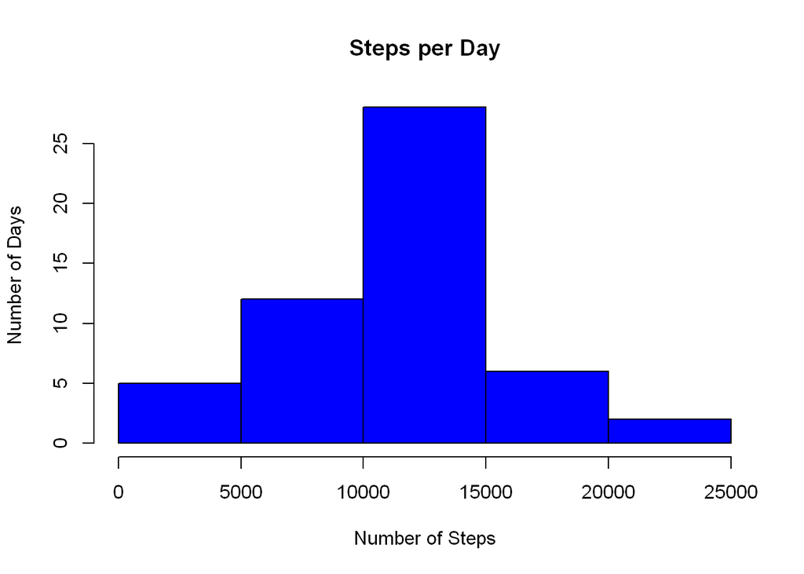

```r
stepsperday <- tapply(data$steps, data$date, sum)
hist( stepsperday , main="Steps per Day" , col = "blue",
     xlab= "Number of Steps", ylab = "Number of Days")
```

```r
mean_steps <- mean(stepsperday, na.rm = TRUE)
median_steps <- median(stepsperday, na.rm = TRUE)
```

The mean value of steps per day is 1.0766 × 10<sup>4</sup> The median value of steps per day is 10765

## What is the average daily activity pattern?

Next analsysis consists of checking differences among intervals of measurement, so about moments of the day. A time series plot is used for that purpose.

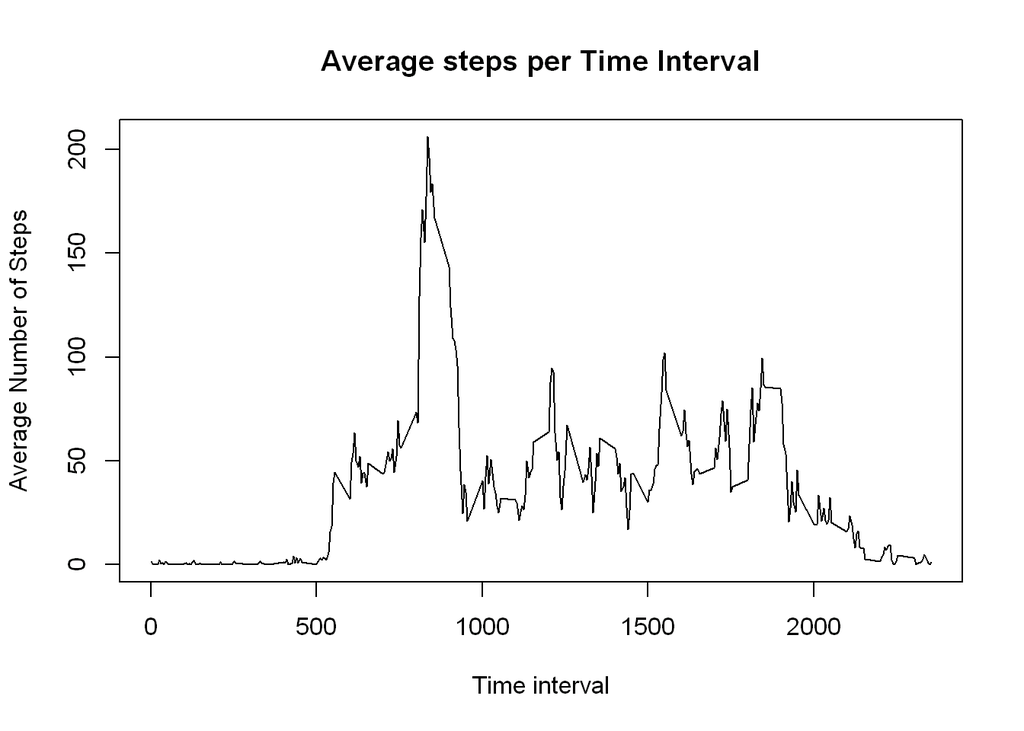

```r
stepsperinterval <- tapply(data$steps[!is.na(data$steps)],
                           data$interval[!is.na(data$steps)], mean)
plot(as.character(unique(data$interval)), stepsperinterval, type = "l",
     main = "Average steps per Time Interval",
     ylab = "Average Number of Steps" ,
     xlab = "Time interval")
```

```r
max_interval <- stepsperinterval[stepsperinterval == max(stepsperinterval)]
```

## Imputing missing values

```r
number_of_na <- sum(is.na(data))
data_noNa <- data
```

In those data there are several missing values, concretelly 2304 missing values. Next code fills the missing values with the mean value of that time interval over the days. The figure below shows the same data as first figure but sustituting missing values.

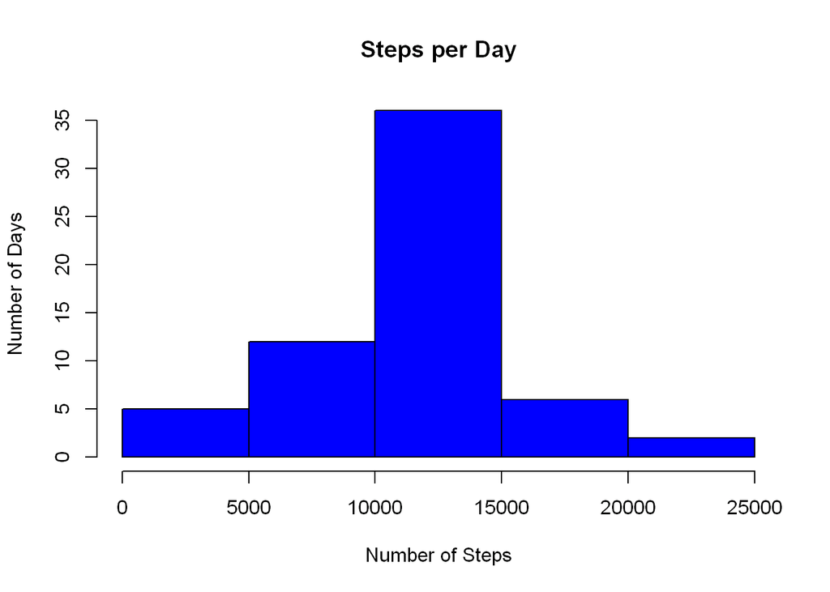

```r
for (index in 1:length(data$steps)) {
    if (is.na(data$steps[index])) {
        data_noNa$steps[index] <- mean(data[data$interval == data$interval[index],1], na.rm = TRUE)
    }
}
stepsperday_noNa <- tapply(data_noNa$steps, data_noNa$date, sum)
hist( stepsperday_noNa , main="Steps per Day" , col = "blue",
     xlab= "Number of Steps", ylab = "Number of Days")
```

## Are there differences in activity patterns between weekdays and weekends?

The last step of the analysis has been to check if there is a difference from weekdays to weekends in the step distribution over day time intervals.

For this analysis, weekdays and weekends have been obtained for the dates in NA removed data and introduced in a new variable called weekday. After that, a new data frame was elaborated calculating steps per interval for both time periods and binding them indetified by a dummy variable. The plot is striaghtforward using lattice package.

```r
wd <- as.POSIXlt(data_noNa$date)
data_noNa$wdays <- ifelse(wd$wday == 0 | wd$wday == 6,
                          c("weekend"), c("weekdays"))
stepsinterval_wend <- tapply(
              data_noNa$steps[data_noNa$wdays == "weekend"],
              data_noNa$interval[data_noNa$wdays == "weekend"], mean)
stepsinterval_wday <- tapply(
              data_noNa$steps[data_noNa$wdays == "weekdays"],
              data_noNa$interval[data_noNa$wdays == "weekdays"], mean)
intervals <- unique(data$interval)
n_intervals <- length(intervals)
data2 <- rbind(
   data.frame(steps = stepsinterval_wend, interval = intervals,
              weekday = rep("weekend" , n_intervals)) ,
   data.frame(steps = stepsinterval_wday, interval = intervals,
              weekday = rep("weekdays" , n_intervals))
               )
library(lattice)
```

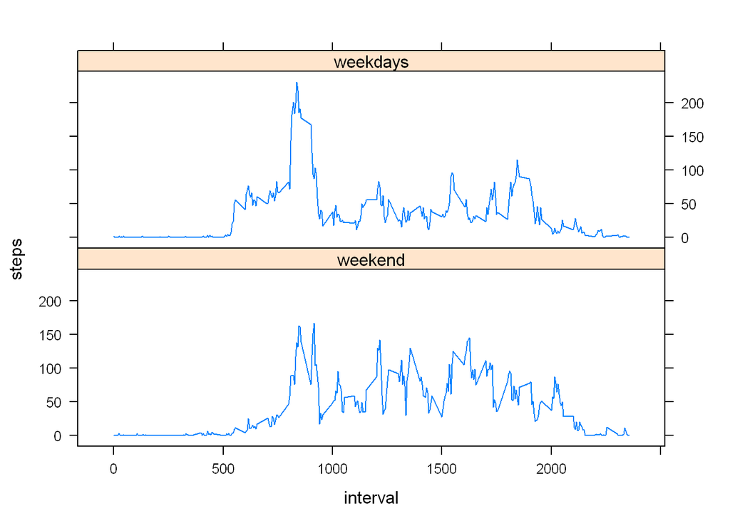

```r
xyplot(steps ~ interval | weekday, data = data2, type = "l" ,layout = c(1, 2))
```

There is a clear difference in the graphical patterns. The stong activity from 8:00 to 9:00 in weekdays becomes a low peak in weekends, reducing 50 steps in average.